# Presentation of the Flood Estimation Toolbox

Martin Durocher

19/12/2019

## Presentation plan

- Project structure
- Tools and Examples
- Graphical interface

## Project structure

- GitHub
  - https://github.com/floodnetProject16/
- CSHShydRology (CRAN)
  - Target advanced users
  - Include basic numerical tools
  - Provide more options
- FloodnetProject16 (to be renamed)
  - Connect with HYDAT
  - Follow guidelines (automatic)
  - Graphical User Interface
- Extra (Aug 2019)

## What is covered?

- At-site flood frequency Analysis
  - Annual maximum discharge (AMAX)
  - Peaks over threshold (POT)
- Regional Frequency Analysis (RFA)
  - L-moment algorithm
  - Independent likelihood
- Prediction at ungauged basins
  - Quantile regression techniques (QRT)
  - Region of Influence + kriging
- Nonstationary

## Project Data

- 1114 studied stations
- Trend tests
- Super regions
- Candidate thresholds
- Descriptors

## Example RFA

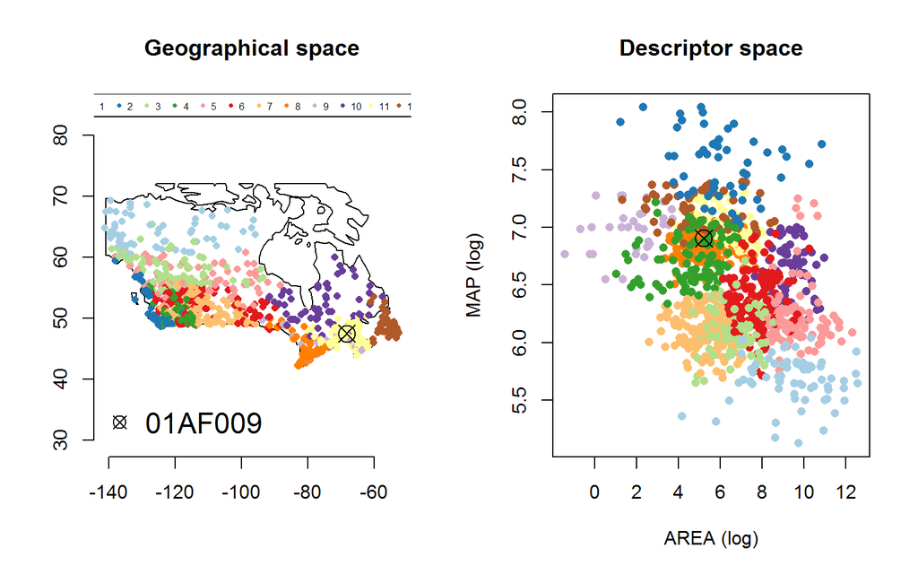

## Example RFA

```r
library(floodnetProject16)
library(CSHShydRology)

## Station of interest and path of the HYDAT database
mystation <- '01AF009'
myreg <- with(gaugedSites,
              station[supreg_km12 == 11 & trend_mk > .05])

db <- 'C:/Data/HYDAT_11AUG19/Hydat.sqlite3'
```

## Example RFA

- Similarity measure based on timing and regularity of the annual maximum events

```r
sdist <- SeasonDistanceData(myreg, db)
an <- AmaxData(myreg, db, target = mystation,
               distance = sdist, size = 20)
```

## Example RFA

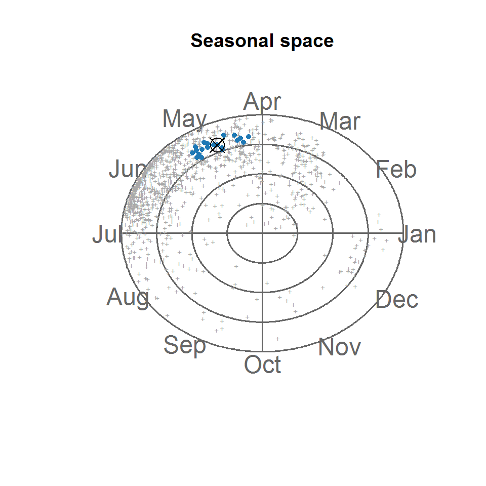

## Example RFA

```r
set.seed(1)
FloodnetPool(an, mystation, period = c(10,100))
```

```
##
## [Updating pooling group]
## [1] "n:20, h:3.8, t:800"
## [1] "n:19, h:2.28, t:767"
```

```
##      site    method distribution period variable      value
## 1 01AF009 pool_amax          gev     10 quantile  59.327145
## 2 01AF009 pool_amax          gev    100 quantile  84.829954
## 3 01AF009 pool_amax          gev     10     rmse   4.648592
## 4 01AF009 pool_amax          gev    100     rmse   7.584507
## 5 01AF009 pool_amax          gev     10    lower  51.275987
## 6 01AF009 pool_amax          gev    100    lower  71.362790
## 7 01AF009 pool_amax          gev     10    upper  69.186800
## 8 01AF009 pool_amax          gev    100    upper 100.652022
```

## Example RFA

- Using HYDAT
  - Connect to DB: `RSQLite`
- Using CSHShydRology
  - Reorganizing the data: `DataWide`.
  - Evaluate seasonality: `SeasonStat`, `SeasonDist`
  - Finding the pooling group: `FindNearest`.
  - Fitting the pooling group: `FitRegLmom`.
  - Updating the pooling group: `PoolRemove`.
  - Estimating intersite correlation: `Intersite`.
  - Evaluating flood quantiles: `predict`

## Example POT

- Same logic apply to the other frequency analysis

```r
set.seed(1)
out <- FloodnetPot('01AF009', db = db, area = 184, u = 20,
                   period = 100, out.model = TRUE)
head(out$qua)
```

```
##      site method distribution period variable     value
## 1 01AF009    pot          gpa    100 quantile  91.48292
## 2 01AF009    pot          gpa    100       se  20.13597
## 3 01AF009    pot          gpa    100    lower  58.69652
## 4 01AF009    pot          gpa    100    upper 136.36445
```

## Example POT

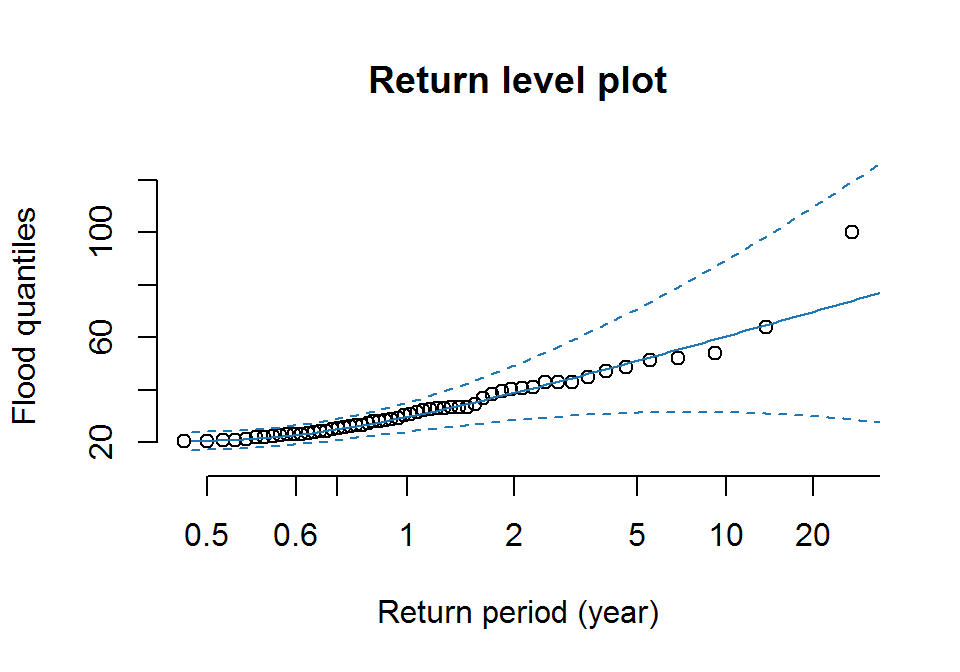

```r
plot(out$fit, ci = TRUE)
```

## Example PUB

```r
xd <- with(descriptors,
  data.frame(
      site = station,
    area = log(area),
    map  = log(map_ws),
    wb   = log(.01 + wb),
    stream = log(.01 + stream),
      elev = elev_ws,
      slope = log(.01 + slope)))

## split my sites
target.id <- (xd$site == mystation)
target <- xd[target.id,]
xd <- xd[-target.id,]
```

## Example PUB

```r
set.seed(1)
FloodnetRoi(target = target, sites = xd, db = db,
            period = 100, size = 30, nsim = 20, verbose = FALSE)
```

```
##      site method period variable     value
## 1 01AF009    QRT    100 quantile  92.40321
## 2 01AF009    QRT    100       se  27.29479
## 3 01AF009    QRT    100    lower  49.06706
## 4 01AF009    QRT    100    upper 134.22377
```

## Main functions

- Data: `AmaxData`, `DailyData`, `DailyPeaksData`
- At-site : `FloodnetAmax`, `FloodnetPot`.
- RFA : `FloodnetPool`, `FloodnetPoolMle`
- Ungauged: `FloodnetRoi`

## Graphical User Interface

- Shiny Apps (web app)
- Features
  - Projects
  - Export CSV
  - Reports*
  - Update DB*
- Graphics
  - Maps: descriptor and geographical space
  - Return levels plot
  - POT diagnostics
  - Comparison plot: Q100, CV

## Graphical User Interface (GUI)

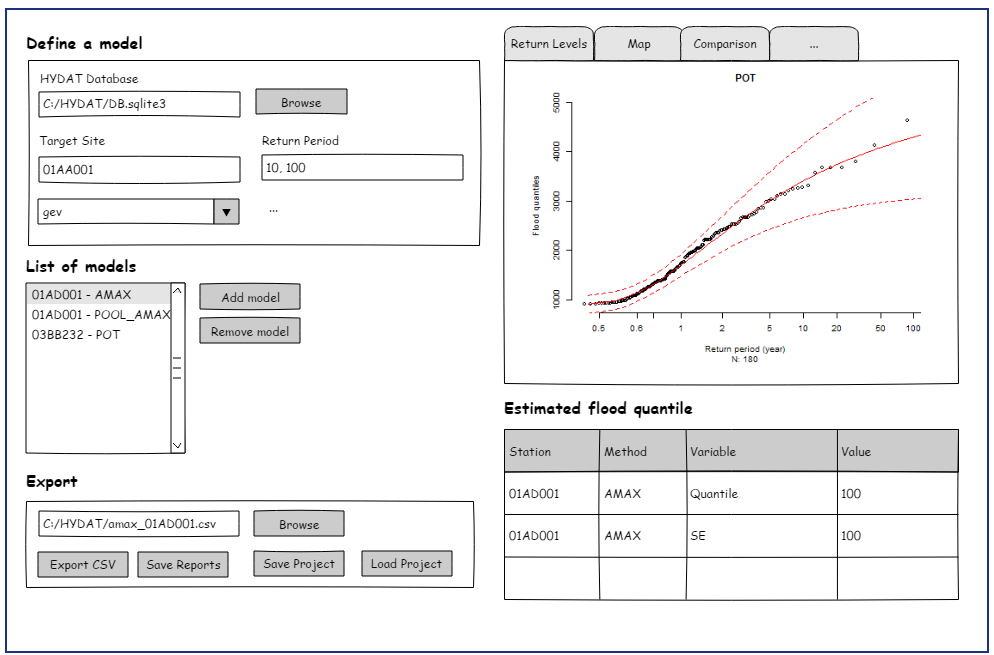

## Extra

- Scripts for updating `gaugedSites`
- Analysis of the 1114 stations

## Thanks

- mdurocher@uwaterloo.ca
- github.com/martindurocher